# Información Inicial

## Análisis de Obesidad

### Realizado por:

Juan Camilo Restrepo

Ailyn Stephanie Rocha

Gabriela María Valenzuela

### Maestro:

Dr. Victor Cruz

### Universidad Anáhuac Mayab

## Objetivo

### OBJETIVO

Analizar las características, los hábitos alimenticios y la actividad física de las personas para los diferentes tipos de obesidad.

# Actividad 1a

## IMC Promedios

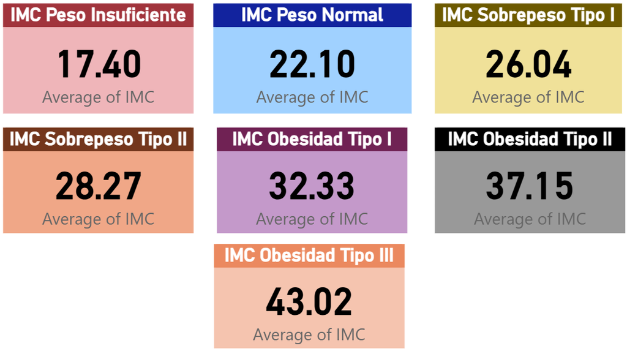

# Actividad 1b

## Análisis de IMC

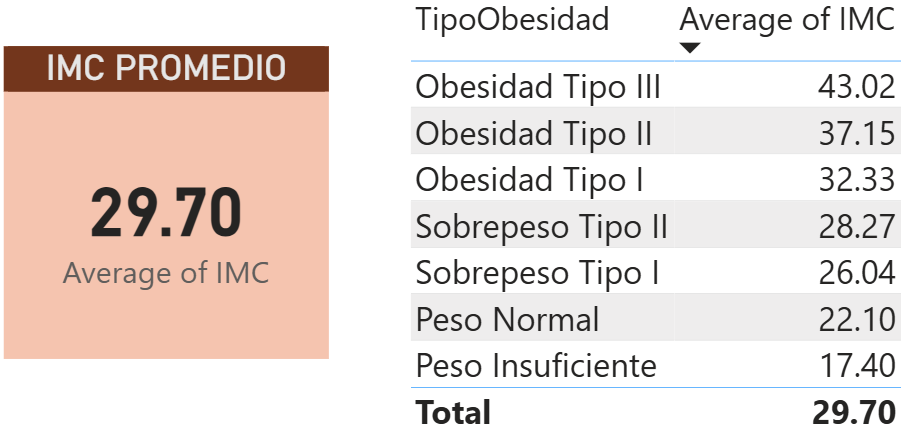

### ANÁLISIS IMC

Más del 50% presenta un IMC promedio mayor a 25, reflejando alta prevalencia de sobrepeso u obesidad, lo que incrementa el riesgo de enfermedades como diabetes e hipertensión.

# Actividad 2

## Diabetes y Antecedentes

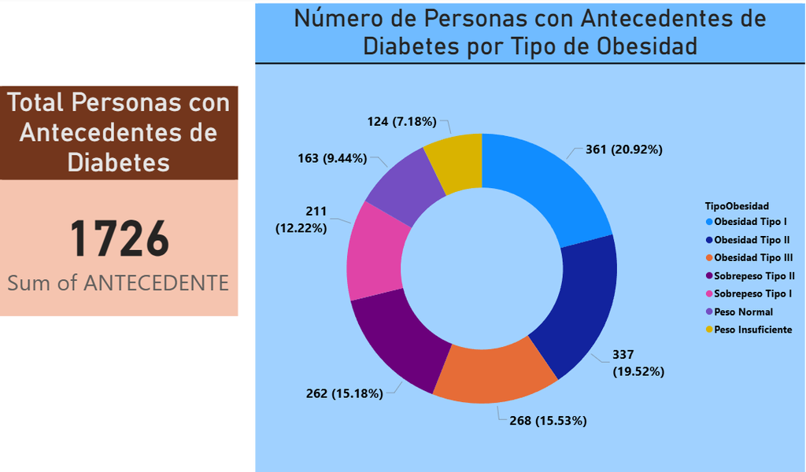

### ANÁLISIS DE DIABETES CON RESPECTO A ANTECEDENTES

El 56% de las personas con antecedentes de diabetes (966 de 1,726) presentan obesidad, lo que evidencia la fuerte relación entre ambas condiciones y la necesidad de acciones preventivas en estos grupos.

# Actividad 3

## Diabetes y Edades

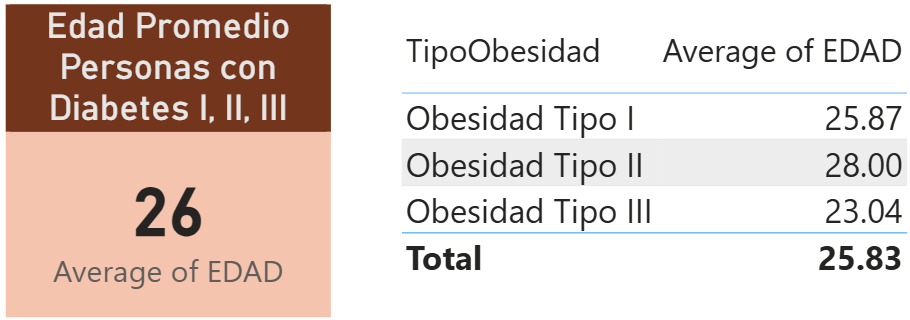

### ANÁLISIS DE DIABETES CON RESPECTO A EDADES

# Actividad 4a

## Transporte e IMC

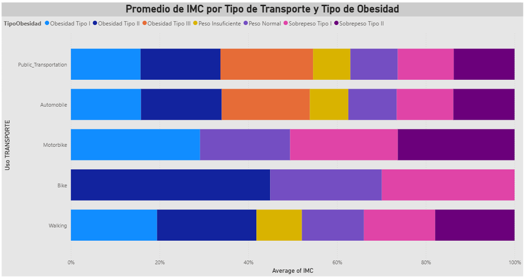

# Actividad 4b

## Tipos de Obesidad

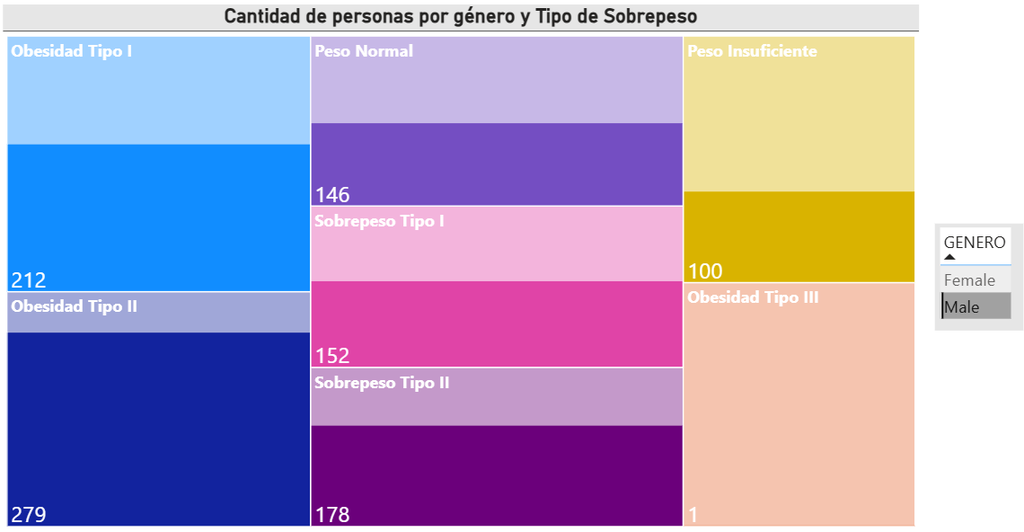

Tipo: Obesidad Tipo II - Count of Género: 279

La mayoría presenta Obesidad Tipo I (368 casos) y Tipo II (338 casos), frente a solo 300 personas con peso normal, lo que refleja una preocupante tendencia al sobrepeso y obesidad en la población analizada.

# Actividad 4c

## Alcohol e IMC

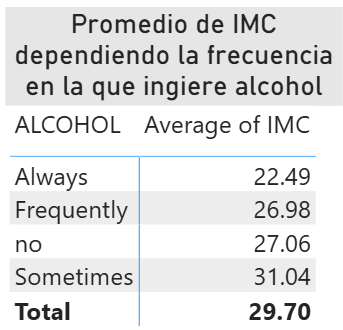

### ANÁLISIS CON RESPECTO AL CONSUMO DE ALCOHOL

El consumo de alcohol se relaciona con el IMC, siendo más alto en quienes beben ocasionalmente y más bajo en quienes beben regularmente, lo que sugiere que el estilo de vida o la dieta podrían influir.

# Actividad 4d

## Comidas e IMC

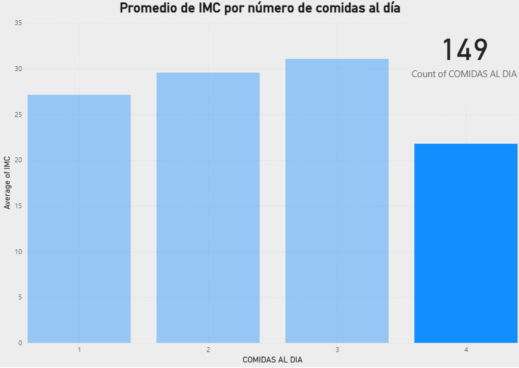

### ANÁLISIS CON RESPECTO A COMIDAS AL DÍA

Comidas al día: 316

Comidas al día: 176

Comidas al día: 1,470

Comidas al día: 149

Las personas que comen 3 veces al día tienen el IMC más alto, mientras que quienes hacen 4 comidas diarias tienen el IMC más bajo, sugiriendo que más comidas podrían ayudar a controlar el peso.

# Actividad 4e

## Monitoreo e IMC

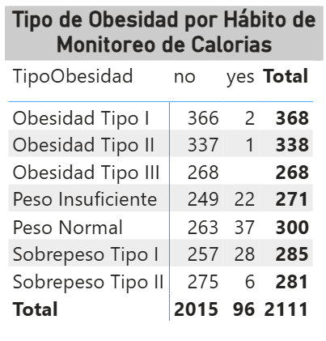

### ANÁLISIS CON RESPECTO AL MONITOREO DE CALORIAS

Quienes no monitorean su consumo de calorías tienden a tener sobrepeso u obesidad, mientras que quienes sí lo hacen tienen más probabilidad de tener un peso normal o insuficiente.

# Actividad 5

## Correlación Edad-IMC

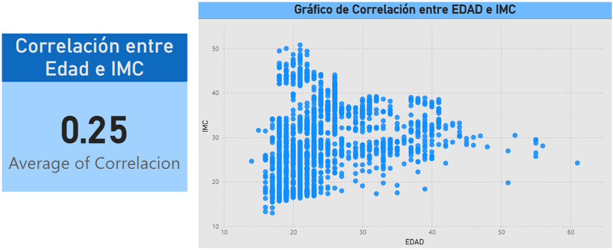

### ANÁLISIS DE CORRELACIÓN EDAD E IMC

El análisis de correlación entre Edad e IMC muestra un coeficiente de 0.25, lo que indica una correlación positiva débil entre ambas variables. Esto significa que, en general, a medida que la edad aumenta, el IMC tiende a aumentar ligeramente, pero la relación no es fuerte.

# Conclusión

## Conclusión General

### CONCLUSIÓN GENERAL

Los datos muestran una tendencia preocupante de obesidad y sobrepeso, influenciada por factores como dieta, estilo de vida y consumo de alcohol. La obesidad está fuertemente vinculada a la diabetes, lo que resalta la importancia de la prevención temprana y el control de estos factores en grupos de riesgo.

# Recomendaciones

## Toma de Decisiones

### TOMA DE DECISIONES

#### Prevención temprana en jóvenes

Lanzar programas educativos para detectar factores de riesgo de diabetes y obesidad desde edades tempranas, enfocándose en hábitos saludables y actividad física.

#### Fomentar el monitoreo calórico

Promover el uso de herramientas para monitorear el consumo calórico, especialmente en personas con antecedentes familiares de diabetes y obesidad.

#### Acceso a comidas saludables

Facilitar opciones alimenticias saludables en comunidades y promover hábitos de comer varias veces al día para mejorar el control del peso y la salud en general.